# Report: YIEDL Experiment 1 (Old vs. New Dataset)

Author

Joe (Degenius Maximus) Chow

Published

April 28, 2025

**Version**: `0.1 (first draft)`

## 1 Introduction

For the Yiedl competition we distribute a daily dataset, with week-to-week targets, which has fewer features than the new dataset given to Numerai for their crypto competition. We should compare the performance of the two dataset under a variety of models and **check if it makes sense to push the adoption of the new dataset** in our competitions.

This report summarises the findings from the first experiment. The ultimate goal is to identify the key performance differences in models trainned using either the old (weekly) or new (daily) YIEDL datasets. For this experiment, I decided to use a large grid search instead of a few fine-tuned models. Here are my reasons:

1. Fine-tuned models (trained based on my previous experience with YIEDL and Numerai) **may introduce survivorship bias**.
2. Training models from a large grid search will likely results in three groups of models: **underfitted**, **about right**, and **overfitted**.
3. These three groups of models can kind of simulate a real-world situation where YIEDL would receive predictions from **newbie**, **intermediate** and **expert** users.
4. If most models trained using daily data show improved out-of-bag predictive performance, this could strongly indicate that daily data is effective, thus **addressing the primary research question**.

## 2 Experiment Set-up

### 2.1 Datasets

The following two datasets from https://yiedl.ai/competition/datasets were used:

1. YIEDL Weekly Data - `dataset_weekly_2025_15.zip`
2. YIEDL Daily Data - `dataset_daily_2025_15.zip`

### 2.2 Training vs. Test Periods

1. **Training**: 2018-04-27 to 2022-10-31
2. **Embargo**: 2022-11-01 to 2022-12-31 (a two-month gap period between training and test to avoid data leakage)
3. **Test**: 2023-01-01 to 2025-04-06

### 2.5 Grid Search

The following parameters were used to build xgboost regression models:

```r
# Define parameters for xgboost
params <- list(objective = "reg:squarederror", # fixed
               eta = 0.01, # fixed
               max_bin = 63, # fixed
               tree_method = "gpu_hist", # fixed
               gpu_id = 0, # fixed
               booster = "gbtree", # fixed

               max_depth = input_params$max_depth, # see below
               max_leaves = 2**input_params$max_depth - 1, # see below
               subsample = input_params$subsample, # see below
               colsample_bytree = input_params$colsample_bytree) # see below

# Train xgboost model
model_weekly <- xgb.train(params = params, # as shown above
                          data = training_dataset, # training dataset for each target
                          nrounds = input_params$nrounds) # see below
```

The dynamic variables for the grid search:

1. `max_depth`: 3, 4, 5, 6, 7, 8, 9
2. `max_leaves`: calculated using `max_depth`
3. `subsample`: 0.5, 0.6, 0.7, 0.8, 0.9, 1.0
4. `colsample_bytree`: 0.05, 0.1, 0.2, 0.3, 0.4, 0.5
5. `round`: 500, 1000, 1500, 2000

### 2.6 Models

The models can be categorised into four groups:

1. 1008 models trained with **weekly data** + `target_neutral` —> predict on **weekly data**
2. 1008 mdels trained with **daily data** + `target_neutral` —> predict on **weekly data**
3. 1008 models trained with **weekly data** + `target_updown` —> predict on **weekly data**
4. 1008 models trained with **daily data** + `target_updown` —> predict on **weekly data**

## 3 Predictions

Here is an example of predictions from models trained with the `neutral` targets:

```
         date   symbol yhat_weekly yhat_daily
       <Date>   <char>       <num>      <num>
1: 2023-01-01     ATOM  0.46437995 0.43139842
2: 2023-01-01      LTC  0.20844327 0.21108179
3: 2023-01-01    MARSH  0.09498681 0.12664908
4: 2023-01-01     UNCX  0.51846966 0.51319261
5: 2023-01-01 UNISTAKE  0.30606860 0.32849604
6: 2023-01-01      TCT  0.01451187 0.01055409
```

Similarly, we can look at the predictions from models trained with the `updown` targets:

```
         date   symbol yhat_weekly  yhat_daily
       <Date>   <char>       <num>       <num>
1: 2023-01-01     ATOM  0.01370640  0.01613749
2: 2023-01-01      LTC  0.00382110  0.00447802
3: 2023-01-01    MARSH  0.00873456  0.00900494
4: 2023-01-01     UNCX  0.00514489  0.01064970
5: 2023-01-01 UNISTAKE  0.00944165  0.01341015
6: 2023-01-01      TCT  0.00662424 -0.13239994
```

## 4 Evaluation Metrics

### 4.1 Primary Metrics

For `target_neutral`, I calculated the date-wise **Spearman correlation** by comparing the predictions from weekly/daily models with the targets. Here is an example:

```
         date  cor_weekly   cor_daily
       <Date>       <num>       <num>
1: 2023-01-01  0.09203025  0.06804244
2: 2023-01-08 -0.04149877 -0.06153740
3: 2023-01-15  0.07896631  0.12185307
4: 2023-01-22  0.09738196  0.11143340
5: 2023-01-29  0.05406949  0.05855512
6: 2023-02-05  0.03582397  0.03980841
```

Similarly, here is an example of the date-wise **RMSE** evaluation for `target_updown`:

```
         date rmse_weekly rmse_daily
       <Date>       <num>      <num>
1: 2023-01-01   0.1931192  0.1804634
2: 2023-01-08   0.3309541  0.2766155
3: 2023-01-15   0.2755370  0.1963707
4: 2023-01-22   0.2757088  0.2634905
5: 2023-01-29   0.4911367  0.4936971
6: 2023-02-05   0.5768729  0.5564189
```

### 4.2 Secondary Metrics

Based on the primary metrics, the following secondary evaluation metrics were calculated for further analysis:

## 5 Comparison (Neutral)

### 5.1 Mean Spearman Correlation

#### 5.1.1 Hypothesis / Expectations

Models trained with daily data should have **higher** mean Spearman correlation when compared to those trained with weekly data.

#### 5.1.2 Observations (Stats)

1. No. of **daily** models with **higher mean correlation** = **1008** out of 1008 (**100%**)
2. Range of **weekly** models’ mean correlation (**cor_mean_wkly**):

```
   Min. 1st Qu.  Median    Mean 3rd Qu.    Max.
 0.1283  0.1370  0.1387  0.1382  0.1399  0.1423
```

3. Range of **daily** models’ mean correlation (**cor_mean_daily**):

```
   Min. 1st Qu.  Median    Mean 3rd Qu.    Max.
 0.1340  0.1433  0.1449  0.1443  0.1459  0.1479
```

4. Range of **raw** performance differences (**cor_mean_daily - cor_mean_wkly**):

```
    Min.  1st Qu.   Median     Mean  3rd Qu.     Max.
0.002133 0.005222 0.006134 0.006158 0.007129 0.012689
```

5. Range of **percentage** differences (%) (**diff / cor_mean_weekly**):

```
   Min. 1st Qu.  Median    Mean 3rd Qu.    Max.
  1.591   3.731   4.400   4.464   5.180   9.893
```

#### 5.1.3 Observations (Charts)

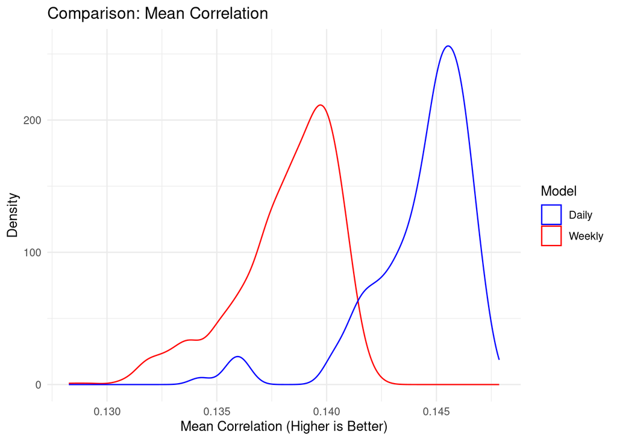

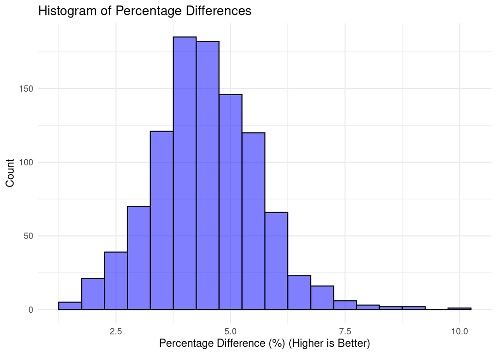

#### 5.1.4 Result Table

Here is the full table of mean correlation comparison.

|  | rsamp | csamp | round | cor_mean_wkly | cor_mean_daily | diff | p_diff |
| --- | --- | --- | --- | --- | --- | --- | --- |
| 1 | 0.5 | 0.05 | 500 | 0.13204 | 0.134463 | 0.002423000000000008 | 1.835049984853081 |
| 2 | 0.5 | 0.05 | 500 | 0.136244 | 0.140064 | 0.00381999999999999 | 2.803793194562689 |
| 3 | 0.5 | 0.05 | 500 | 0.138545 | 0.142926 | 0.004380999999999996 | 3.16214948211772 |
| 4 | 0.5 | 0.05 | 500 | 0.139136 | 0.144465 | 0.005329 | 3.830065547378105 |
| 5 | 0.5 | 0.05 | 500 | 0.139218 | 0.144783 | 0.005564999999999987 | 3.997327931732956 |
| 6 | 0.5 | 0.05 | 500 | 0.138694 | 0.145332 | 0.006637999999999977 | 4.786075821592842 |
| 7 | 0.5 | 0.05 | 500 | 0.137811 | 0.144214 | 0.00640300000000002 | 4.646218371537845 |
| 8 | 0.6 | 0.05 | 500 | 0.131745 | 0.134244 | 0.002499000000000001 | 1.896846180120688 |
| 9 | 0.6 | 0.05 | 500 | 0.137155 | 0.140105 | 0.002950000000000008 | 2.150851226714307 |
| 10 | 0.6 | 0.05 | 500 | 0.139371 | 0.142791 | 0.003420000000000006 | 2.45388208450826 |

[output cut: 998 more lines]

**Notes**:

1. `rsamp` = `subsample`
2. `csamp` = `colsample_bytree`
3. `round` = `round`
4. `cor_mean_wkly`= mean correlation of weekly models’ predictions
5. `cor_mean_daily`= mean correlation of daily models’ predictions
6. `diff` = `cor_mean_daily` - `cor_mean_wkly` (i.e. positive differences mean the daily models are better)
7. `p_diff`= `diff` / `cor_mean_wkly * 100` percentage difference (%)

### 5.2 Sharpe Ratio

#### 5.2.1 Hypothesis / Expectations

Models trained with daily data should have **higher** Sharpe ratio (based on date-wise Spearman correlation) when compared to those trained with weekly data.

#### 5.2.2 Observations (Stats)

1. No. of **daily** models with **higher Sharpe ratio** = **963** out of 1008 (**95.54%**)
2. Range of **weekly** models’ Sharpe ratio (**sharpe_wkly**):

```
   Min. 1st Qu.  Median    Mean 3rd Qu.    Max.
  1.608   1.756   1.817   1.804   1.856   1.963
```

3. Range of **daily** models’ Sharpe ratio (**sharpe_daily**):

```
   Min. 1st Qu.  Median    Mean 3rd Qu.    Max.
  1.628   1.810   1.879   1.861   1.924   1.981
```

```
    Min.  1st Qu.   Median     Mean  3rd Qu.     Max.
-0.05193  0.03792  0.05631  0.05696  0.07685  0.16861
```

```
   Min. 1st Qu.  Median    Mean 3rd Qu.    Max.
 -2.647   2.128   3.121   3.160   4.250   9.403
```

#### 5.2.3 Observations (Charts)

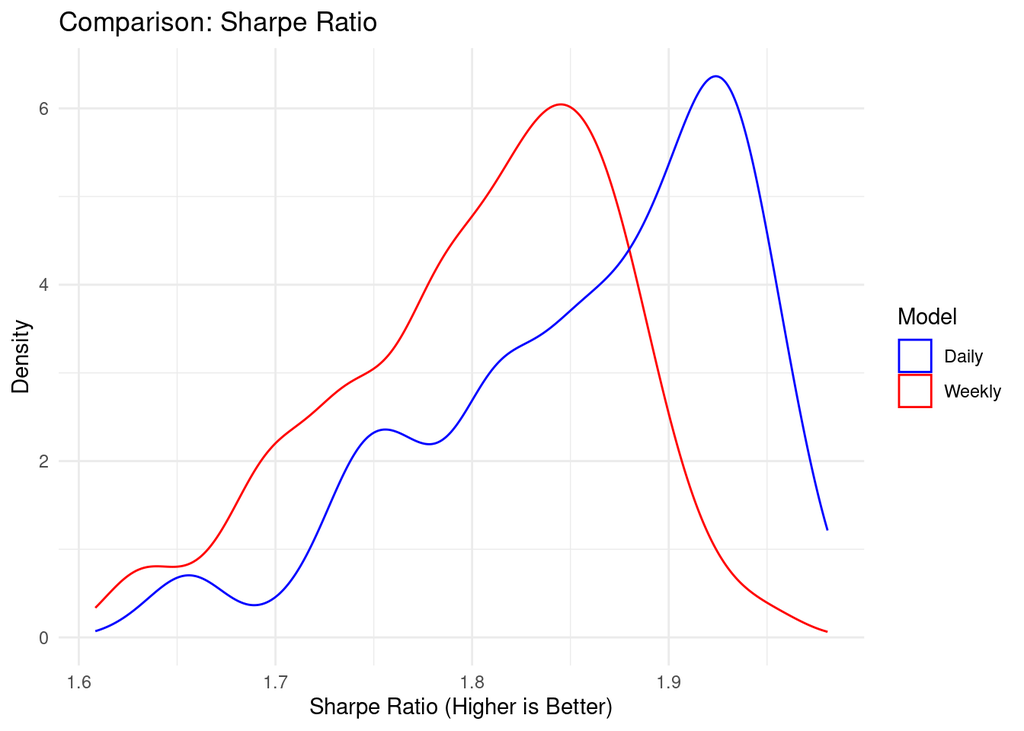

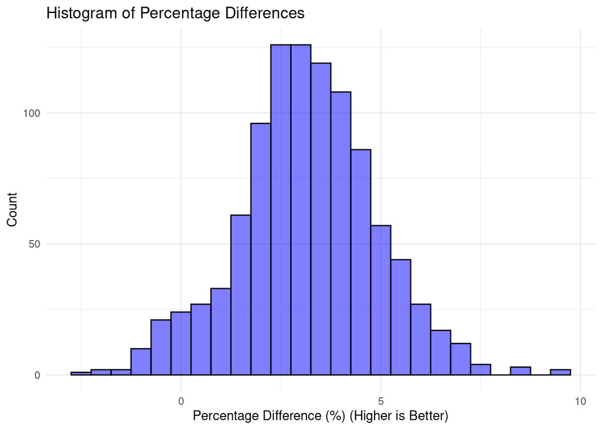

#### 5.2.4 Result Table

|  | rsamp | csamp | round | sharpe_wkly | sharpe_daily | diff | p_diff |
| --- | --- | --- | --- | --- | --- | --- | --- |
| 1 | 0.5 | 0.05 | 500 | 1.646688 | 1.633199 | -0.01348899999999986 | -0.8191594278940433 |
| 2 | 0.5 | 0.05 | 500 | 1.72103 | 1.722009 | 0.0009789999999998411 | 0.05688454007192444 |
| 3 | 0.5 | 0.05 | 500 | 1.78846 | 1.78539 | -0.003069999999999906 | -0.1716560616396177 |
| 4 | 0.5 | 0.05 | 500 | 1.822561 | 1.830812 | 0.008251000000000008 | 0.4527146142159306 |
| 5 | 0.5 | 0.05 | 500 | 1.878061 | 1.86392 | -0.01414099999999996 | -0.7529574385496509 |
| 6 | 0.5 | 0.05 | 500 | 1.872686 | 1.900391 | 0.02770499999999987 | 1.479425808704709 |
| 7 | 0.5 | 0.05 | 500 | 1.91911 | 1.902534 | -0.01657600000000015 | -0.8637337098967827 |
| 8 | 0.6 | 0.05 | 500 | 1.639978 | 1.636027 | -0.003951000000000038 | -0.2409178659713751 |
| 9 | 0.6 | 0.05 | 500 | 1.748944 | 1.716992 | -0.03195199999999998 | -1.826930993788251 |
| 10 | 0.6 | 0.05 | 500 | 1.807406 | 1.780679 | -0.02672700000000017 | -1.478749102304638 |

[output cut: 998 more lines]

**Notes**:

1. `rsamp` = `subsample`
2. `csamp` = `colsample_bytree`
3. `round` = `round`
4. `sharpe_wkly`= Sharpe ratio of weekly models’ predictions
5. `sharpe_daily`= Sharpe ratio of daily models’ predictions
6. `diff` = `sharpe_daily` - `sharpe_wkly` (i.e. positive differences mean the daily models are better)
7. `p_diff`= `diff` / `sharpe_wkly * 100` percentage difference (%)

## 6 Comparison (Updown)

### 6.1 Trimmed Mean RMSE

#### 6.1.1 Hypothesis / Expectations

Models trained with daily data should have **lower** RMSE when compared to those trained with weekly data. Since a few outliers are expected in the mean values, trimmed mean (i.e. 10% data in both ends removed) is used for this analysis.

#### 6.1.2 Observations (Stats)

1. No. of **daily** models with **lower trimmed mean RMSE** = **1008** out of 1008 (**100%**)
2. Range of **weekly** models’ trimmed mean RMSE (**rmse_tm_wkly**):

```
   Min. 1st Qu.  Median    Mean 3rd Qu.    Max.
 0.4583  0.5473  0.6009  0.5956  0.6421  0.7439
```

3. Range of **daily** models’ trimmed mean RMSE (**rmse_tm_daily**):

```
   Min. 1st Qu.  Median    Mean 3rd Qu.    Max.
 0.4218  0.4712  0.5039  0.5050  0.5342  0.6428
```

4. Range of **raw** performance differences (**rmse_tm_daily - rmse_tm_wkly**):

```
    Min.  1st Qu.   Median     Mean  3rd Qu.     Max.
-0.14027 -0.10743 -0.09196 -0.09059 -0.07554 -0.03166
```

5. Range of **percentage** differences (%) (**diff / rmse_tm_wkly**):

```
   Min. 1st Qu.  Median    Mean 3rd Qu.    Max.
-20.836 -16.974 -15.217 -15.030 -13.471  -6.203
```

#### 6.1.3 Observations (Charts)

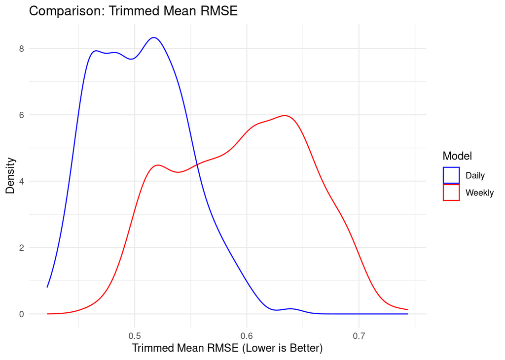

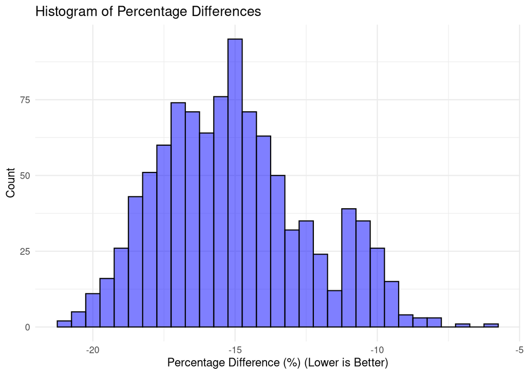

#### 6.1.4 Result Table

|  | rsamp | csamp | round | rmse_tm_wkly | rmse_tm_daily | diff | p_diff |
| --- | --- | --- | --- | --- | --- | --- | --- |
| 1 | 0.5 | 0.05 | 500 | 0.475437 | 0.426475 | -0.04896200000000001 | -10.29831502386226 |
| 2 | 0.5 | 0.05 | 500 | 0.493355 | 0.438582 | -0.05477299999999996 | -11.10214754081746 |
| 3 | 0.5 | 0.05 | 500 | 0.49849 | 0.446429 | -0.05206099999999997 | -10.44374009508716 |
| 4 | 0.5 | 0.05 | 500 | 0.504126 | 0.449355 | -0.05477099999999996 | -10.86454576831982 |
| 5 | 0.5 | 0.05 | 500 | 0.505826 | 0.452068 | -0.05375799999999997 | -10.62776527896944 |
| 6 | 0.5 | 0.05 | 500 | 0.508947 | 0.457321 | -0.05162600000000006 | -10.1436888320395 |
| 7 | 0.5 | 0.05 | 500 | 0.509201 | 0.460986 | -0.04821500000000001 | -9.468755952953746 |
| 8 | 0.6 | 0.05 | 500 | 0.468939 | 0.423173 | -0.04576599999999997 | -9.759478311678059 |
| 9 | 0.6 | 0.05 | 500 | 0.49387 | 0.434082 | -0.05978799999999995 | -12.1060198027821 |
| 10 | 0.6 | 0.05 | 500 | 0.494893 | 0.444778 | -0.05011500000000002 | -10.12643137001332 |

[output cut: 998 more lines]

**Notes**:

1. `rsamp` = `subsample`
2. `csamp` = `colsample_bytree`
3. `round` = `round`
4. `rmse_tm_wkly`= trimmed mean RMSE of weekly models’ predictions
5. `rmse_tm_daily`= trimmed mean RMSE of daily models’ predictions
6. `diff` = `rmse_tm_daily` - `rmse_tm_wkly` (i.e. negative differences mean the daily models are better)
7. `p_diff`= `diff` / `rmse_tm_wkly * 100` percentage difference (%)

## 7 Conclusions

- A large grid search (1,008 combinations of different xgboost parameters) was used for this experiments.
- Pairs of weekly and daily models (trained using the same parameters) were used to produce out-of-bag predictions on the same weekly test data (i.e. from 2023-01-01).
- Early analysis of the performance comparison **suggests that daily data improves out-of-bag predictive performance**.

### 7.1 Summary (Target Neutral)

- **All** daily models show **HIGHER mean Spearman correlation** compared to weekly models, indicating **better** performance.
- **Most (96%)** daily models show **HIGHER Sharpe ratio** compared to weekly models, indicating **better** performance.
- (more metrics to be added in the next version)

### 7.2 Summary (Target Updown)

- **All** daily models show **LOWER trimmed mean RMSE** compared to weekly models, indicating **better** performance.
- (more metrics to be added in the next version)